# Week 3 assignment

## Max Joseph

I am part of the Analytics Hub with Earth Lab and Research Computing at the University of Colorado Boulder. My background is in hierarchical Bayesian modeling and disease dynamics, but much of my current work involves writing scientific software to make data more useful. I am hoping to become more proficient with remotely sensed data by taking this course, so that I can more effectively integrate data from different sources.

## Project summary

A lot of people climb rocks in Boulder, CO. Some do so after work. Let’s say you’re planning to go climbing in Boulder Canyon on a specific day, in a specific time interval. What crags will have shade vs. sun, and when?

This is a question that climbers usually answer by eyeballing a topo map and forming a mental model of the sun at the time that they’re climbing. However, with science, we can do better. Specifically, given a digital elevation model and a model of solar radiation that incorporates hill shading, we can actually get a pretty good prediction for amount of direct sunlight at a specific location at a specific time.

Dream Canyon is a popular location for climbing (and bathing) in the summer, because there is abundant shade. However, human error (bad predictions for direct sun conditions) can lead to unfortunate circumstances - sunburn, hot shoes, sweaty hands, etc. that make rock climbing less fun.

Using the OpenTopo data for Dream Canyon, the `insol` package, and the [Mountain Project API](https://www.mountainproject.com/data) I’d like to develop an interactive R Shiny app to facilitate decision making for climbers. This app could include animations of insolation with a slider bar so that you can move the time of day (and a fill-in box for date), and visualize sun conditions at a crag.

## Loading lidar rasters

Let’s see what files are available in the lidar folder.

```r
library(raster)
library(rasterVis)
# what data are available?
data_dir <- "~/Documents/NEONDI-2016/NEONdata/D17-California/TEAK/2013/lidar/"
files <- list.files(data_dir)
files
```

```
## [1] "TEAK_lidarAspect.tif" "TEAK_lidarCHM.tif"    "TEAK_lidarDSM.tif"
## [4] "TEAK_lidarDTM.tif"    "TEAK_lidarSlope.tif"
```

There are five tif files in the lidar folder. Let’s load them as a list.

```r
paths <- paste0(data_dir, files)
r_list <- lapply(paths, raster)
r_list
```

```
## [[1]]
## class       : RasterLayer
## dimensions  : 577, 543, 313311  (nrow, ncol, ncell)
## resolution  : 1, 1  (x, y)
## extent      : 325963, 326506, 4102905, 4103482  (xmin, xmax, ymin, ymax)
## coord. ref. : +proj=utm +zone=11 +datum=WGS84 +units=m +no_defs +ellps=WGS84 +towgs84=0,0,0
## data source : /home/max/Documents/NEONDI-2016/NEONdata/D17-California/TEAK/2013/lidar/TEAK_lidarAspect.tif
## names       : TEAK_lidarAspect
## values      : 0, 359.9936  (min, max)
##
##
## [[2]]
## class       : RasterLayer
## dimensions  : 577, 543, 313311  (nrow, ncol, ncell)
## resolution  : 1, 1  (x, y)
## extent      : 325963, 326506, 4102905, 4103482  (xmin, xmax, ymin, ymax)
## coord. ref. : +proj=utm +zone=11 +datum=WGS84 +units=m +no_defs +ellps=WGS84 +towgs84=0,0,0
## data source : /home/max/Documents/NEONDI-2016/NEONdata/D17-California/TEAK/2013/lidar/TEAK_lidarCHM.tif
## names       : TEAK_lidarCHM
## values      : 0, 55.68  (min, max)
##
##
## [[3]]
## class       : RasterLayer
## dimensions  : 577, 543, 313311  (nrow, ncol, ncell)
## resolution  : 1, 1  (x, y)
## extent      : 325963, 326506, 4102905, 4103482  (xmin, xmax, ymin, ymax)
## coord. ref. : +proj=utm +zone=11 +datum=WGS84 +units=m +no_defs +ellps=WGS84 +towgs84=0,0,0
## data source : /home/max/Documents/NEONDI-2016/NEONdata/D17-California/TEAK/2013/lidar/TEAK_lidarDSM.tif
## names       : TEAK_lidarDSM
## values      : 2172.83, 2391.83  (min, max)
##
##
## [[4]]
## class       : RasterLayer
## dimensions  : 577, 543, 313311  (nrow, ncol, ncell)
## resolution  : 1, 1  (x, y)
## extent      : 325963, 326506, 4102905, 4103482  (xmin, xmax, ymin, ymax)
## coord. ref. : +proj=utm +zone=11 +datum=WGS84 +units=m +no_defs +ellps=WGS84 +towgs84=0,0,0
## data source : /home/max/Documents/NEONDI-2016/NEONdata/D17-California/TEAK/2013/lidar/TEAK_lidarDTM.tif
## names       : TEAK_lidarDTM
## values      : 2172.83, 2385.23  (min, max)
##
##
## [[5]]
## class       : RasterLayer
## dimensions  : 577, 543, 313311  (nrow, ncol, ncell)
## resolution  : 1, 1  (x, y)
## extent      : 325963, 326506, 4102905, 4103482  (xmin, xmax, ymin, ymax)
## coord. ref. : +proj=utm +zone=11 +datum=WGS84 +units=m +no_defs +ellps=WGS84 +towgs84=0,0,0
## data source : /home/max/Documents/NEONDI-2016/NEONdata/D17-California/TEAK/2013/lidar/TEAK_lidarSlope.tif
## names       : TEAK_lidarSlope
## values      : 0.02894329, 79.48859  (min, max)
```

## Creating a raster stack

Each raster in the list has the same projection, extent, and resolution. We can stack these rasters to make a RasterStack.

```r
r_stack <- stack(r_list)
r_stack
```

```
## class       : RasterStack
## dimensions  : 577, 543, 313311, 5  (nrow, ncol, ncell, nlayers)
## resolution  : 1, 1  (x, y)
## extent      : 325963, 326506, 4102905, 4103482  (xmin, xmax, ymin, ymax)
## coord. ref. : +proj=utm +zone=11 +datum=WGS84 +units=m +no_defs +ellps=WGS84 +towgs84=0,0,0
## names       : TEAK_lidarAspect, TEAK_lidarCHM, TEAK_lidarDSM, TEAK_lidarDTM, TEAK_lidarSlope
## min values  :     0.000000e+00,  0.000000e+00,  2.172830e+03,  2.172830e+03,    2.894329e-02
## max values  :        359.99356,      55.68000,    2391.82983,    2385.22998,        79.48859
```

## Plotting the rasters

To plot these, I’ll use some functions from RasterVis.

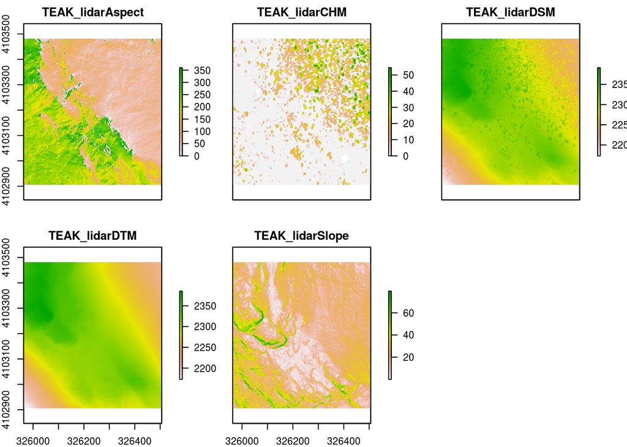

```r
plot(r_stack)
```

How correlated are the values among the layers?

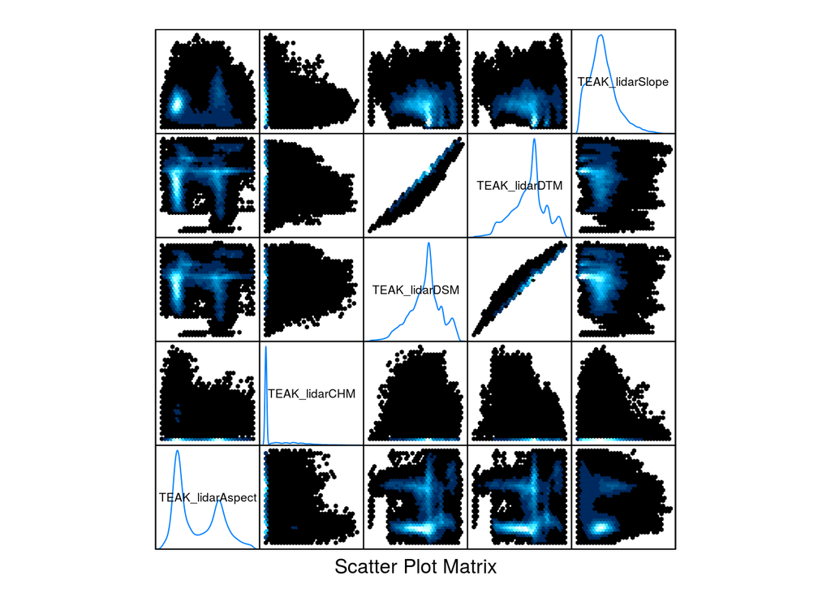

```r
splom(r_stack)
```

How about a level plot?

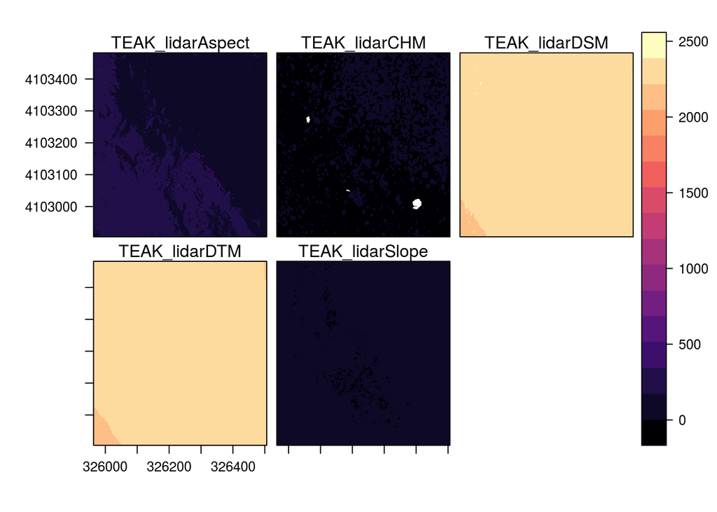

```r
levelplot(r_stack)
```

Looks horrible, because all of the values among rasters are on different scales.

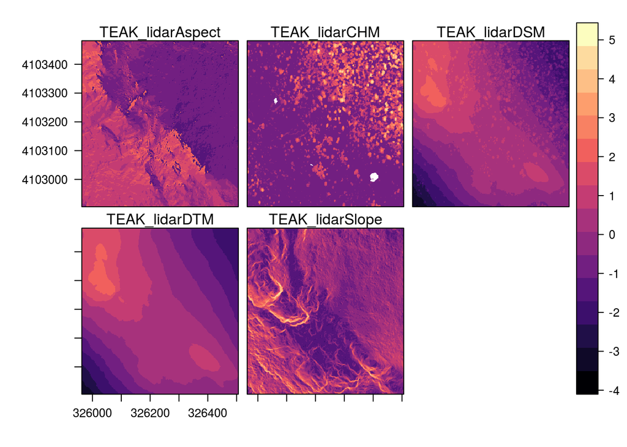

```r
levelplot(scale(r_stack))
```

Less horrible, but still bad because of outliers in the CHM (crown height) layer, which has a long right tail (a few pixels with very large crown height values).

## Generating raster histograms

We can use the `hist` function, but I’ll suppress warnings.

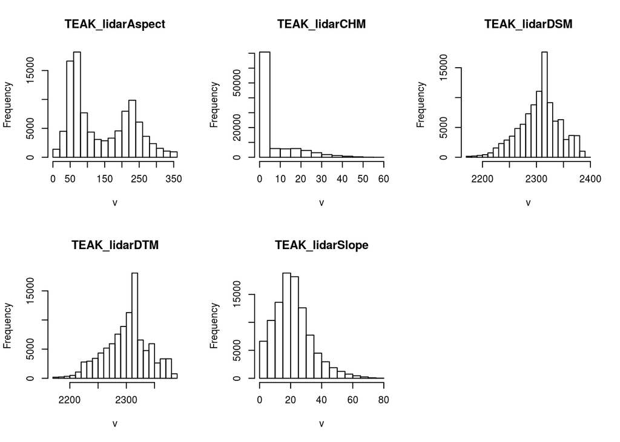

```r
hist(r_stack)
```

## Discussion

The `raster` package makes all of these operations fairly easy as long as everything has the same extent, projection, and resolution. R markdown is nice because the documents are portable.